# Generalized Linear Models

László Kovács

2026-07-14

## 1. Poisson Regression

Consider the dataset car.csv. It contains $n=67856$ contracts in force between 2004 and 2005 in the portfolio of an Australian insurance company providing compulsory motor third-party liability insurance (MTPL insurance). We have $10$ variables available.

- **veh_value**: Vehicle value in ten-thousand Australian dollars
- **exposure**: Percentage of the period during which the policy was active
- **clm**: Whether a claim occurred during the observation period (0 = no, 1 = yes)
- **numclaims**: Number of claims during the observation period
- **claimcst0**: Claim amount in Australian dollars (0 if no claim occurred)
- **veh_body**: Vehicle body type (bus, truck, passenger car, etc.)
- **veh_age**: Categorized vehicle age: 1 (newest), 2, 3, 4
- **gender**: Driver’s gender: M (male), F (female)
- **area**: Driver’s residential region: A, B, C, D, E, F
- **agecat**: Categorized age of driver: 1 (youngest), 2, 3, 4, 5, 6

So, let’s load the file to an R data frame!

```r
cars <- read.csv("car.csv")
str(cars)
```

```
## 'data.frame':    67856 obs. of  10 variables:
##  $ veh_value: num  1.06 1.03 3.26 4.14 0.72 2.01 1.6 1.47 0.52 0.38 ...
##  $ exposure : num  0.304 0.649 0.569 0.318 0.649 ...
##  $ clm      : int  0 0 0 0 0 0 0 0 0 0 ...
##  $ numclaims: int  0 0 0 0 0 0 0 0 0 0 ...
##  $ claimcst0: num  0 0 0 0 0 0 0 0 0 0 ...
##  $ veh_body : chr  "HBACK" "HBACK" "UTE" "STNWG" ...
##  $ veh_age  : int  3 2 2 2 4 3 3 2 4 4 ...
##  $ gender   : chr  "F" "F" "F" "F" ...
##  $ area     : chr  "C" "A" "E" "D" ...
##  $ agecat   : int  2 4 2 2 2 4 4 6 3 4 ...
```

Great, we have all the $67856$ observations and the $10$ variables. Before, we investigate further, let’s set all the categorical variables (`veh_age`, `area`, `agecat`, etc.) to `factor` data type.

```r
cars$clm <- as.factor(cars$clm)
cars$veh_body <- as.factor(cars$veh_body)
cars$veh_age <- as.factor(cars$veh_age)
cars$gender <- as.factor(cars$gender)
cars$area <- as.factor(cars$area)
cars$agecat <- as.factor(cars$agecat)
str(cars)
```

```
## 'data.frame':    67856 obs. of  10 variables:
##  $ veh_value: num  1.06 1.03 3.26 4.14 0.72 2.01 1.6 1.47 0.52 0.38 ...
##  $ exposure : num  0.304 0.649 0.569 0.318 0.649 ...
##  $ clm      : Factor w/ 2 levels "0","1": 1 1 1 1 1 1 1 1 1 1 ...
##  $ numclaims: int  0 0 0 0 0 0 0 0 0 0 ...
##  $ claimcst0: num  0 0 0 0 0 0 0 0 0 0 ...
##  $ veh_body : Factor w/ 13 levels "BUS","CONVT",..: 4 4 13 11 4 5 8 4 4 4 ...
##  $ veh_age  : Factor w/ 4 levels "1","2","3","4": 3 2 2 2 4 3 3 2 4 4 ...
##  $ gender   : Factor w/ 2 levels "F","M": 1 1 1 1 1 2 2 2 1 1 ...
##  $ area     : Factor w/ 6 levels "A","B","C","D",..: 3 1 5 4 3 3 1 2 1 2 ...
##  $ agecat   : Factor w/ 6 levels "1","2","3","4",..: 2 4 2 2 2 4 4 6 3 4 ...
```

All is set! Now, let’s examine the distribution for the number of claims (`numclaims` variable) in these two years examined.

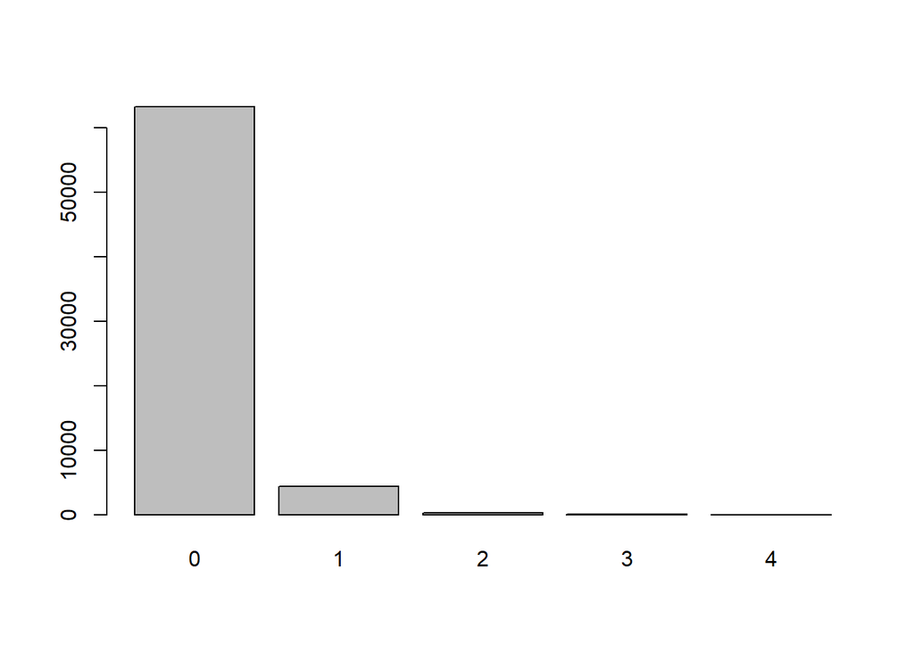

```r
barplot(table(cars$numclaims))
```

```r
var(cars$numclaims) > mean(cars$numclaims)
```

```
## [1] TRUE
```

Looks like a discrete variable with higher variance than mean. Which could mean one thing, the number of claims (let’s denote it with $Y$) follows a *negative binomial distribution*. That is… for every observation $i$, the number of claims follows a Poisson distribution, but the $\lambda$ expected value is specific for every $i$-th observation. See Secion 5.4 of Chapter 1 for details.
$$y_i \sim Poi(\lambda_i)$$

So, we could build a linear regression model on these individual expected values. Let’s first use two predictor variables: $x_1$ the vehicle value and $x_2$ if the driver is female.
$$\lambda_i = \beta_0 + \beta_1x_{1i} + \beta_2x_{2i}$$

Only problem is that we know that Poisson expected value is always positive $\lambda_i>0$, but the regression predictions $\beta_0 + \beta_1x_{1i} + \beta_2x_{2i}$ can be anywhere between $\pm\infty$. However, a logarithm quickly solves this problem.
$$\log(\lambda_i) = \beta_0 + \beta_1x_{1i} + \beta_2x_{2i}$$

So, the model for $\lambda_i$ is **multiplicative**.
$$\lambda_i=\exp(\beta_0) \times \exp(\beta_1)^{x_{1i}} \times \exp(\beta_2)^{x_{2i}}$$

### 1.1. Maximum Likelihood for Poisson Regression

Once we have this model setup, it is easy to **estimate the $\beta_j$ coefficients via maximum likelihood** (MLE). We apply the same thing as with the simple linear regression in Section 7 of Chapter 7: we use the density function of the Poisson distribution, but the logarithm of $\lambda$ is generated by the $\beta_0 + \beta_1x_{1i} + \beta_2x_{2i}$ regression equation.

Let’s define the negative log-likelihood function of the model in R.

```r
cars$female <- ifelse(cars$gender=="F", 1, 0) # create dummy for females

neg_ll_poi <- function(Betas) {
  log_lambdas <- Betas[1] + Betas[2]*cars$veh_value + Betas[3]*cars$female
  return(-sum(log(dpois(x = cars$numclaims,
                        lambda = exp(log_lambdas)))))
}

# try the function with some random Betas
neg_ll_poi(c(-2, 0.1, 0.1))
```

```
## [1] 20615.52
```

Looks like the function works. Awesome, now let’s make `optim` work. Let’s ask for the Hessian matrix of the log-likelihood function as well to have standard errors on the coefficients.

```r
poi_reg_mle <- optim(c(-2, 0.1, 0.1), neg_ll_poi, hessian = TRUE)
poi_reg_mle$value # optimized negative log-likelihood
```

```
## [1] 18089.93
```

```r
poi_reg_mle$par # estimated Betas
```

```
## [1] -2.73490269  0.05244620  0.03330374
```

Great, we have the model estimated:
$$\log(\lambda_i) = -2.7 + 0.05x_{1i} + 0.03x_{2i}$$

Because of the log transform, regression coefficients are interpreted exponentially:
$$\lambda_i=\exp(-2.7) \times \exp(0.05)^{x_{1i}} \times \exp(0.03)^{x_{2i}}$$

Furthermore, due to the exponential the interpretation is multiplicative.

```r
exp(poi_reg_mle$par)
```

```
## [1] 0.06490032 1.05384587 1.03386452
```

But are these effects significant? Like are poor female drivers really $3.4\%$ worse than males or is it just sampling error? Let’s construct the coefficient table of the model like we did for simple regression in Section 7 of Chapter 7.

```r
varcov_betas <- solve(poi_reg_mle$hessian)
se_betas <- sqrt(diag(varcov_betas))

coef_table <- data.frame(coef=poi_reg_mle$par,
                         se = se_betas)
rownames(coef_table) <- c("Intercept", "veh_value", "female")
coef_table$z_value <- coef_table$coef/coef_table$se
coef_table$p_value <- round(2*pnorm(-abs(coef_table$z_value)),5)
coef_table
```

|  | coef | se | z_value | p_value |
| --- | --- | --- | --- | --- |
| Intercept | -2.73490269 | 0.03055184 | -89.516784 | 0.0000 |
| veh_value | 0.05244620 | 0.01056942 | 4.962071 | 0.0000 |
| female | 0.03330374 | 0.02893893 | 1.150828 | 0.2498 |

Oh well, looks like the gender stereotypes are really just that: stereotypes. The $+3.4\%$ for the expected claim number of female drivers is not a significant coefficient on any of the common $\alpha$ significance levels!

We can also calculate $AIC$ and $BIC$ with the formulas defined in Section 5 of Chapter 3 to decide whether this model has a better fit on our target variable $Y$ than a Poission regression with some other predictor variables.  
Note that the **number of estimated parameters is $p=3$ here** since we estimated the $\lambda_i$ with $3$ $\beta_j$ coefficients.

```r
p <- length(poi_reg_mle$par)
n <- nrow(cars)

aic <- 2*p + 2*poi_reg_mle$value
bic <- log(n)*p + 2*poi_reg_mle$value
```

### 1.2. The built-in R Function

Of course, everything we did here can be obtained with a built-in R function as well. It is called `glm` (an abbrevaiation for generalized linear models), and it works just like `lm` for simple linear regression models. It has 1 extra parameter compared to `lm`, the `family` parameter where we define that the target variable has a $Poi(\lambda_i)$ distribution and we transform the $\lambda_i$ values with a $\log$ function before applying the regression equation on it.  
Not that `glm` generates a `male` dummy variable from the original `gender` variable, so the coefficient will of course have a different sign, and it’ll show that males have an average claim number that is lower by $3.3\%$ ($\exp(\beta_{\text{male}})-1=-0.033$) than that of females while the vehicle value remains unchanged.

```r
poi_reg_fun <- glm(numclaims~veh_value+gender, family = poisson(link = "log"), data = cars)
summary(poi_reg_fun)
```

```
##
## Call:
## glm(formula = numclaims ~ veh_value + gender, family = poisson(link = "log"),
##     data = cars)
##
## Deviance Residuals:
##     Min       1Q   Median       3Q      Max
## -0.8933  -0.3845  -0.3780  -0.3723   4.8918
##
## Coefficients:
##             Estimate Std. Error  z value Pr(>|z|)
## (Intercept) -2.70175    0.02626 -102.866  < 2e-16 ***
## veh_value    0.05256    0.01057    4.974 6.56e-07 ***
## genderM     -0.03353    0.02894   -1.159    0.247
## ---
## Signif. codes:  0 '***' 0.001 '**' 0.01 '*' 0.05 '.' 0.1 ' ' 1
##
## (Dispersion parameter for poisson family taken to be 1)
##
##     Null deviance: 26768  on 67855  degrees of freedom
## Residual deviance: 26745  on 67853  degrees of freedom
## AIC: 36186
##
## Number of Fisher Scoring iterations: 6
```

Great, about the same results, they are probably bit more accurate as in `glm`, You have a more finetuned version of `optim` applied, so the estimated coefficients are a bit more accurate here, but there is no substantial difference.

You can get the model log-likelihood as well. Compared to our version, it’s basically the same. Same is true if You compare the $AIC$ values.

```r
c(logLik(poi_reg_fun), poi_reg_mle$value)
```

```
## [1] -18089.93  18089.93
```

```r
c(AIC(poi_reg_fun), aic)
```

```
## [1] 36185.86 36185.86
```

However, note that the `summary` does not show the log-likelihood itself, instead it shows so called **deviances**. Now, what the hell are these? First, we need to introduce three concepts:

- **Full (or saturated) model**: A model that contains as many parameters as observations, and therefore fits every observation perfectly.
- **Null model**: A model that contains only an intercept. So $\lambda_i = \beta_0$. This is what we’ve been fitting with maximum likelihood in Chapter 3 or with method of moments in Chapter 1.

The fit of the actual model will fall somewhere between these two extremes. With these concepts the deviances can be defined:

- Model **Residual Deviance**: Twice the increase in log-likelihood when the full model is used instead of the actual model defined with the $\beta$ parameters: $D=2(\log[L(\text{full})]-\log[L(\beta)])$
- **Null Deviance** ($D_0$): The total deviance of the null model.

Note that **Residual Deviance has the same role here as the $SSE$ in the OLS regression**, as it is decreases if the model error decreases (i.e. model fit on the observed data improves). And **Null Deviance has the same role here as the $SST$ in the OLS regression**, as it shows the model fit error when we don’t use any $x$ predictor variables. So it is the “error” around the simple sample mean since that is the MLE for $E(Y)$ if we have no predictors to use.

With these in mind we can introduce **McFadden’s pseudo $R^2$ measure** as $R^2 = 1-D/D_0$ with the same logic as $R^2=1-SSE/SST$. It shows by what percentage is our model better than the null model. But be careful, it’s just a **pseudo** $R^2$, so it **not as nicely scaled between $0$ and $1$ as the original** $R^2$. Practically, this means that **it can be around $0$ even if we have significant variables in our model** on all common $\alpha$ levels. This is the case now.

```r
1 - poi_reg_fun$deviance/poi_reg_fun$null.deviance
```

```
## [1] 0.0008645958
```

So, this is **not as great of a measure than the original** $R^2$, therefore use it **with caution**.

### 1.3. Further options with the `glm` function

We can handle the fact that not all cars are observed for the full 2 years for 2004-2005. Like because the car insurance was cancelled as the car was sold. Like for the 1st car, we could only see the claim history for $30.4\%$ of these two years.

```r
cars$exposure[1]
```

```
## [1] 0.3039014
```

So, we want to consider that this car was only observed for $0.304$ times of the total period, so its true expected claim number for the total 2-year-period is actually $\lambda_1/0.304$. We can inlcude this for all cars in the regression equation. Let’s denote the exposure of the $i$-th observation as $N_i$. With this, we’ll have the following model:
$$\lambda_i/N_i = \exp(\beta_0) \times \exp(\beta_1)^{x_{1i}} \times \exp(\beta_2)^{x_{2i}}$$

By transforming this so that $lambda_i$ is expressed, we find that we just need to add $\log(N_i)$ as an extra term in the regression equation without any coefficients:
$$\log(\lambda_i) = \beta_0 + \beta_1x_{1i} + \beta_2x_{2i} + \log(N_i)$$

We can do this through the `offset` parameter in `glm`.

```r
poi_reg_fun <- glm(numclaims~veh_value+gender,
                   family = poisson(link = "log"),
                   data = cars,
                   offset = log(cars$exposure))
summary(poi_reg_fun)
```

```
##
## Call:
## glm(formula = numclaims ~ veh_value + gender, family = poisson(link = "log"),
##     data = cars, offset = log(cars$exposure))
##
## Deviance Residuals:
##     Min       1Q   Median       3Q      Max
## -1.2022  -0.4572  -0.3494  -0.2242   4.3802
##
## Coefficients:
##             Estimate Std. Error z value Pr(>|z|)
## (Intercept) -1.93898    0.02625 -73.876  < 2e-16 ***
## veh_value    0.05418    0.01055   5.133 2.85e-07 ***
## genderM     -0.05146    0.02894  -1.778   0.0754 .
## ---
## Signif. codes:  0 '***' 0.001 '**' 0.01 '*' 0.05 '.' 0.1 ' ' 1
##
## (Dispersion parameter for poisson family taken to be 1)
##
##     Null deviance: 25507  on 67855  degrees of freedom
## Residual deviance: 25481  on 67853  degrees of freedom
## AIC: 34922
##
## Number of Fisher Scoring iterations: 6
```

The results have changed a bit, now the negative coefficient of male drivers increased by roughly $0.02$, and it is significant at $\alpha=10\%$, but still not at $\alpha=5\%$.

Let’s see if this mildly significant effect on male claim number being lower on average is just confounding effect from some other variable: extend the model with the other potential predictor variables.

```r
poi_reg_extended <- glm(numclaims~veh_value+gender+veh_body+veh_age+area+agecat,
                        family = poisson(link = "log"),
                        data = cars,
                        offset = log(cars$exposure))
AIC(poi_reg_extended, poi_reg_fun)
```

|  | df | AIC |
| --- | --- | --- |
| poi_reg_extended | 28 | 34822.51 |
| poi_reg_fun | 3 | 34922.13 |

```r
BIC(poi_reg_extended, poi_reg_fun)
```

|  | df | BIC |
| --- | --- | --- |
| poi_reg_extended | 28 | 35078.01 |
| poi_reg_fun | 3 | 34949.50 |

Based on $AIC$ model improved with the new variables, based on $BIC$, it did not. So, let’s see the coefficient significance of the extended model! What might be omitted to improve on te more strict $BIC$?

```r
summary(poi_reg_extended)
```

```
##
## Call:
## glm(formula = numclaims ~ veh_value + gender + veh_body + veh_age +
##     area + agecat, family = poisson(link = "log"), data = cars,
##     offset = log(cars$exposure))
##
## Deviance Residuals:
##     Min       1Q   Median       3Q      Max
## -0.9069  -0.4521  -0.3457  -0.2212   4.5350
##
## Coefficients:
##                Estimate Std. Error z value Pr(>|z|)
## (Intercept)   -0.667803   0.326382  -2.046  0.04075 *
## veh_value      0.023980   0.017251   1.390  0.16451
## genderM       -0.026181   0.030135  -0.869  0.38495
## veh_bodyCONVT -1.677911   0.668319  -2.511  0.01205 *
## veh_bodyCOUPE -0.514222   0.337512  -1.524  0.12762
## veh_bodyHBACK -0.975986   0.318672  -3.063  0.00219 **
## veh_bodyHDTOP -0.829563   0.327953  -2.530  0.01142 *
## veh_bodyMCARA -0.369072   0.409609  -0.901  0.36757
## veh_bodyMIBUS -0.987654   0.350494  -2.818  0.00483 **
## veh_bodyPANVN -0.855177   0.339270  -2.521  0.01171 *
## veh_bodyRDSTR -0.567799   0.660305  -0.860  0.38984
## veh_bodySEDAN -0.923014   0.318063  -2.902  0.00371 **
## veh_bodySTNWG -0.906750   0.318239  -2.849  0.00438 **
## veh_bodyTRUCK -0.944163   0.328476  -2.874  0.00405 **
## veh_bodyUTE   -1.108652   0.322203  -3.441  0.00058 ***
## veh_age2       0.054363   0.044623   1.218  0.22312
## veh_age3      -0.055849   0.048233  -1.158  0.24691
## veh_age4      -0.114908   0.056801  -2.023  0.04307 *
## areaB          0.053158   0.042802   1.242  0.21425
## areaC          0.005108   0.038994   0.131  0.89577
## areaD         -0.110402   0.052973  -2.084  0.03715 *
## areaE         -0.031935   0.057878  -0.552  0.58111
## areaF          0.063729   0.066158   0.963  0.33541
## agecat2       -0.173250   0.054187  -3.197  0.00139 **
## agecat3       -0.230051   0.052896  -4.349 1.37e-05 ***
## agecat4       -0.256934   0.052744  -4.871 1.11e-06 ***
## agecat5       -0.474475   0.059120  -8.026 1.01e-15 ***
## agecat6       -0.453279   0.067686  -6.697 2.13e-11 ***
## ---
## Signif. codes:  0 '***' 0.001 '**' 0.01 '*' 0.05 '.' 0.1 ' ' 1
##
## (Dispersion parameter for poisson family taken to be 1)
##
##     Null deviance: 25507  on 67855  degrees of freedom
## Residual deviance: 25332  on 67828  degrees of freedom
## AIC: 34823
##
## Number of Fisher Scoring iterations: 6
```

Gender and vehicle value are the two variables that are not significant on any common $\alpha$ significance levels. It’s logical that vehicle value is a confounder as it most likely expresses the effects of vehicle age and the vechicle body types. Let’s try removing these two predictors!

```r
poi_reg_extended <- glm(numclaims~veh_body+veh_age+area+agecat,
                        family = poisson(link = "log"),
                        data = cars,
                        offset = log(cars$exposure))
AIC(poi_reg_extended, poi_reg_fun)
```

|  | df | AIC |
| --- | --- | --- |
| poi_reg_extended | 26 | 34820.98 |
| poi_reg_fun | 3 | 34922.13 |

```r
BIC(poi_reg_extended, poi_reg_fun)
```

|  | df | BIC |
| --- | --- | --- |
| poi_reg_extended | 26 | 35058.24 |
| poi_reg_fun | 3 | 34949.50 |

The $BIC$ is still not satisfied. Investigate further!

```r
summary(poi_reg_extended)
```

```
##
## Call:
## glm(formula = numclaims ~ veh_body + veh_age + area + agecat,
##     family = poisson(link = "log"), data = cars, offset = log(cars$exposure))
##
## Deviance Residuals:
##     Min       1Q   Median       3Q      Max
## -0.8985  -0.4521  -0.3460  -0.2213   4.5532
##
## Coefficients:
##                Estimate Std. Error z value Pr(>|z|)
## (Intercept)   -0.611682   0.321709  -1.901 0.057256 .
## veh_bodyCONVT -1.526527   0.658769  -2.317 0.020491 *
## veh_bodyCOUPE -0.499902   0.337390  -1.482 0.138427
## veh_bodyHBACK -0.987460   0.318209  -3.103 0.001915 **
## veh_bodyHDTOP -0.819113   0.327894  -2.498 0.012486 *
## veh_bodyMCARA -0.329835   0.408607  -0.807 0.419542
## veh_bodyMIBUS -0.970300   0.350333  -2.770 0.005612 **
## veh_bodyPANVN -0.864094   0.339217  -2.547 0.010855 *
## veh_bodyRDSTR -0.519928   0.659283  -0.789 0.430331
## veh_bodySEDAN -0.925994   0.317916  -2.913 0.003583 **
## veh_bodySTNWG -0.885088   0.317931  -2.784 0.005371 **
## veh_bodyTRUCK -0.940395   0.328383  -2.864 0.004187 **
## veh_bodyUTE   -1.107842   0.322175  -3.439 0.000585 ***
## veh_age2       0.040850   0.043445   0.940 0.347082
## veh_age3      -0.085385   0.043090  -1.982 0.047529 *
## veh_age4      -0.164123   0.044584  -3.681 0.000232 ***
## areaB          0.051626   0.042778   1.207 0.227496
## areaC          0.003946   0.038977   0.101 0.919371
## areaD         -0.109084   0.052918  -2.061 0.039267 *
## areaE         -0.030349   0.057846  -0.525 0.599825
## areaF          0.068747   0.066070   1.041 0.298100
## agecat2       -0.172843   0.054178  -3.190 0.001421 **
## agecat3       -0.229309   0.052889  -4.336 1.45e-05 ***
## agecat4       -0.257461   0.052743  -4.881 1.05e-06 ***
## agecat5       -0.474815   0.059105  -8.033 9.48e-16 ***
## agecat6       -0.457768   0.067583  -6.773 1.26e-11 ***
## ---
## Signif. codes:  0 '***' 0.001 '**' 0.01 '*' 0.05 '.' 0.1 ' ' 1
##
## (Dispersion parameter for poisson family taken to be 1)
##
##     Null deviance: 25507  on 67855  degrees of freedom
## Residual deviance: 25334  on 67830  degrees of freedom
## AIC: 34821
##
## Number of Fisher Scoring iterations: 6
```

Next weak link is area as it does not have significant dummies at $\alpha=1\%$. Sayonara area.

```r
poi_reg_extended <- glm(numclaims~veh_body+veh_age+agecat,
                        family = poisson(link = "log"),
                        data = cars,
                        offset = log(cars$exposure))
AIC(poi_reg_extended, poi_reg_fun)
```

|  | df | AIC |
| --- | --- | --- |
| poi_reg_extended | 21 | 34821.84 |
| poi_reg_fun | 3 | 34922.13 |

```r
BIC(poi_reg_extended, poi_reg_fun)
```

|  | df | BIC |
| --- | --- | --- |
| poi_reg_extended | 21 | 35013.46 |
| poi_reg_fun | 3 | 34949.50 |

$BIC$ still not satisfied. We can stop as based on variable significances, as we don’t have dummies that can be omitted as in each dummy, we have at least one category that is significant at $\alpha=1\%$. These are probably significant effects even if we consider Bonferroni corrections (see Section 8 of Chapter 5) as well, since we don’t have that many categories even in the vehicle body types to cancel a p-value lower than $0.1\%$.

```r
summary(poi_reg_extended)
```

```
##
## Call:
## glm(formula = numclaims ~ veh_body + veh_age + agecat, family = poisson(link = "log"),
##     data = cars, offset = log(cars$exposure))
##
## Deviance Residuals:
##     Min       1Q   Median       3Q      Max
## -0.9012  -0.4525  -0.3464  -0.2215   4.5301
##
## Coefficients:
##               Estimate Std. Error z value Pr(>|z|)
## (Intercept)   -0.60602    0.32002  -1.894 0.058263 .
## veh_bodyCONVT -1.52138    0.65842  -2.311 0.020852 *
## veh_bodyCOUPE -0.49878    0.33686  -1.481 0.138691
## veh_bodyHBACK -0.98946    0.31773  -3.114 0.001845 **
## veh_bodyHDTOP -0.82380    0.32780  -2.513 0.011965 *
## veh_bodyMCARA -0.34923    0.40843  -0.855 0.392518
## veh_bodyMIBUS -0.96918    0.34992  -2.770 0.005610 **
## veh_bodyPANVN -0.86285    0.33876  -2.547 0.010862 *
## veh_bodyRDSTR -0.51845    0.65889  -0.787 0.431367
## veh_bodySEDAN -0.92915    0.31749  -2.927 0.003427 **
## veh_bodySTNWG -0.89131    0.31777  -2.805 0.005034 **
## veh_bodyTRUCK -0.95912    0.32827  -2.922 0.003481 **
## veh_bodyUTE   -1.11938    0.32206  -3.476 0.000509 ***
## veh_age2       0.04240    0.04344   0.976 0.329029
## veh_age3      -0.08494    0.04308  -1.971 0.048673 *
## veh_age4      -0.16387    0.04458  -3.676 0.000237 ***
## agecat2       -0.16988    0.05416  -3.137 0.001709 **
## agecat3       -0.22956    0.05286  -4.343 1.41e-05 ***
## agecat4       -0.25925    0.05271  -4.919 8.71e-07 ***
## agecat5       -0.47804    0.05903  -8.099 5.56e-16 ***
## agecat6       -0.46605    0.06746  -6.909 4.90e-12 ***
## ---
## Signif. codes:  0 '***' 0.001 '**' 0.01 '*' 0.05 '.' 0.1 ' ' 1
##
## (Dispersion parameter for poisson family taken to be 1)
##
##     Null deviance: 25507  on 67855  degrees of freedom
## Residual deviance: 25345  on 67835  degrees of freedom
## AIC: 34822
##
## Number of Fisher Scoring iterations: 6
```

We can experiment by merging not significant dummies into an “*other*” category, but at this point we’re stopping and go with the model that has improved $AIC$ and not so much lower $BIC$ than the original model with 2 predictors. :)

Notice that we did not need to worry about any assumption on using the p-values of the coefficients as we now due to the **Cramer-Rao inequality** (see the details in Section 5 of Chapter 4) that maximum likelihood estimators are always efficient if the assumption on the distribution of $Y$ is correct, and we have checked that in the beginning!

## 2. Gamma Regression

Now, once we have the expected number of claims estimated, let’s see only those insured cars that have reported at least 1 claim and see average amount paid per 1 claim.

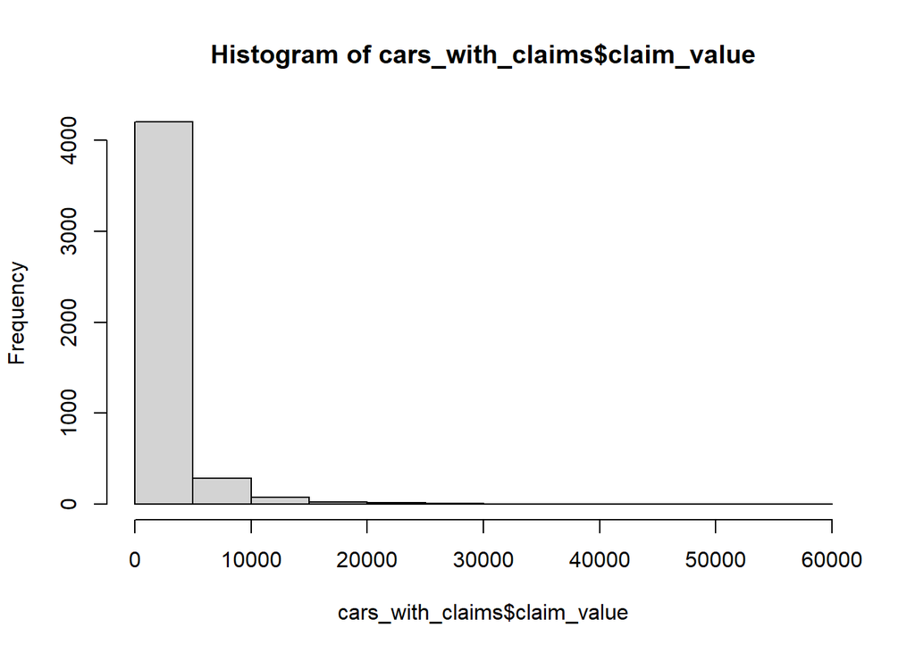

```r
cars_with_claims <- cars[cars$claimcst0>0,]
cars_with_claims$claim_value <- cars_with_claims$claimcst0/cars_with_claims$numclaims
hist(cars_with_claims$claim_value)
```

Looks like a continuous distribution with a long right tail. Let’s try a Gamma distribution with $\alpha,\theta$ parameters.

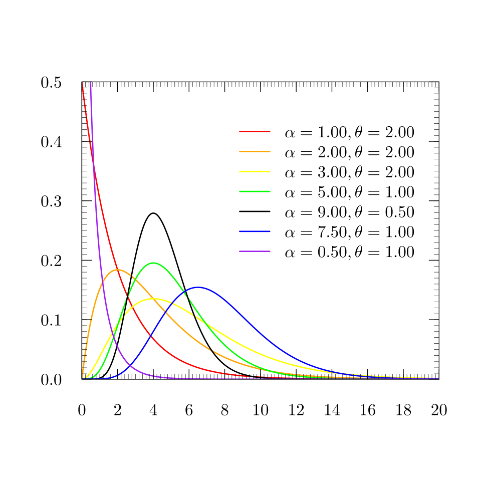

If the claim amount $Y$ is taken as $Y \sim G(\alpha,\theta)$ distributed, its expected value is the following.
$$E(Y)=\alpha\theta$$

We can make this expected value different for every $i$ by writing a regression equation for $\alpha$, as that is the parameter based on the density function plot above that influences the central tendency of the density function. Since it is always a positive parameter, we’ll need the log-transform again.
$$\log(\alpha_i)=\beta_0 + \beta_1x_{1i} +...+ \beta_kx_{ki}$$

Hence in the end, we have the following model to be estimated:
$$E(y_i)=\alpha_i\theta=\exp(\beta_0 + \beta_1x_{1i} +...+ \beta_kx_{ki})\theta$$

We can easily estimate it with `glm` the same way as with a Poisson Regression. We don’t deal with exposures now as it is dealt with the model for number of claims. And now we are examining if the claim has happened, then what is the expected value of it. So, we have everything that we need. Note that $\theta$ is estimated as $\hat{\theta}_{ML}=3.065$. It was handled in the same way as the $\sigma$ of the normal distribution was in Section 7 of Chapter 7.

```r
gamma_reg <- glm(claim_value ~ veh_value + veh_body + veh_age + gender + area + agecat,
                 family = Gamma(link = "log"),
                 data = cars_with_claims)
summary(gamma_reg)
```

```
##
## Call:
## glm(formula = claim_value ~ veh_value + veh_body + veh_age +
##     gender + area + agecat, family = Gamma(link = "log"), data = cars_with_claims)
##
## Deviance Residuals:
##     Min       1Q   Median       3Q      Max
## -1.9484  -1.3438  -0.8074   0.0598   7.1210
##
## Coefficients:
##               Estimate Std. Error t value Pr(>|t|)
## (Intercept)    6.98190    0.60358  11.567  < 2e-16 ***
## veh_value      0.02926    0.03562   0.821 0.411522
## veh_bodyCONVT  0.69403    1.17679   0.590 0.555377
## veh_bodyCOUPE  0.71276    0.62320   1.144 0.252805
## veh_bodyHBACK  0.59379    0.58861   1.009 0.313125
## veh_bodyHDTOP  0.48214    0.60504   0.797 0.425562
## veh_bodyMCARA -0.65816    0.75190  -0.875 0.381440
## veh_bodyMIBUS  0.79824    0.64413   1.239 0.215315
## veh_bodyPANVN  0.57234    0.62643   0.914 0.360948
## veh_bodyRDSTR -0.99752    1.37406  -0.726 0.467899
## veh_bodySEDAN  0.44719    0.58768   0.761 0.446727
## veh_bodySTNWG  0.41023    0.58845   0.697 0.485747
## veh_bodyTRUCK  0.62943    0.60633   1.038 0.299275
## veh_bodyUTE    0.50108    0.59477   0.842 0.399567
## veh_age2       0.07907    0.08059   0.981 0.326559
## veh_age3       0.12305    0.08787   1.400 0.161497
## veh_age4       0.20756    0.10492   1.978 0.047956 *
## genderM        0.17311    0.05457   3.172 0.001523 **
## areaB         -0.01624    0.07771  -0.209 0.834438
## areaC          0.09087    0.07096   1.281 0.200426
## areaD         -0.01070    0.09610  -0.111 0.911334
## areaE          0.17390    0.10553   1.648 0.099463 .
## areaF          0.40234    0.12148   3.312 0.000934 ***
## agecat2       -0.17709    0.09799  -1.807 0.070785 .
## agecat3       -0.28355    0.09542  -2.972 0.002978 **
## agecat4       -0.25864    0.09546  -2.709 0.006766 **
## agecat5       -0.36700    0.10667  -3.441 0.000586 ***
## agecat6       -0.29438    0.12201  -2.413 0.015876 *
## ---
## Signif. codes:  0 '***' 0.001 '**' 0.01 '*' 0.05 '.' 0.1 ' ' 1
##
## (Dispersion parameter for Gamma family taken to be 3.065347)
##
##     Null deviance: 7338.6  on 4623  degrees of freedom
## Residual deviance: 7135.4  on 4596  degrees of freedom
## AIC: 78869
##
## Number of Fisher Scoring iterations: 7
```

Coefficients are also interpreted exponentially in a multiplicative manner as this follows from the model equation.

```r
exp(gamma_reg$coefficients)
```

```
##   (Intercept)     veh_value veh_bodyCONVT veh_bodyCOUPE veh_bodyHBACK
##  1076.9616374     1.0296885     2.0017622     2.0396084     1.8108299
## veh_bodyHDTOP veh_bodyMCARA veh_bodyMIBUS veh_bodyPANVN veh_bodyRDSTR
##     1.6195404     0.5178030     2.2216375     1.7724075     0.3687945
## veh_bodySEDAN veh_bodySTNWG veh_bodyTRUCK   veh_bodyUTE      veh_age2
##     1.5639166     1.5071688     1.8765439     1.6505044     1.0822826
##      veh_age3      veh_age4       genderM         areaB         areaC
##     1.1309399     1.2306669     1.1889974     0.9838879     1.0951247
##         areaD         areaE         areaF       agecat2       agecat3
##     0.9893551     1.1899340     1.4953204     0.8377037     0.7531049
##       agecat4       agecat5       agecat6
##     0.7720989     0.6928112     0.7449964
```

In this case, we might try a regression that assumes a different (right-tailed) distribution on the target variable of claim values (e.g. Pareto, Weibull) and build a regression model on that distribution’s expected value. Maybe we’ll have a better fit with that distribution. This can be checked also by comparing the $IC$ values. Since if another distribution better describes the target variable, then You’ll hae lowe negative log-likelihood in that model even with the same predictor variables included.

## 3. Generalized Linear Models

Now, let’s summarize based on these two examples what these Generalized Linear Models (GLMs) know.

We assume on the target variable $Y$ that the **individual $y_i$ outcomes are independent and follow a distribution with individually differing $E(y_i)$ expected values but of the same distribution type** (Poisson, Normal, Gamma, Bernoulli, etc.).

The individual expected values can be estimated as a linear function after being transformed by a differentiable and monotonic link function $g$ (e.g. logarithm).
$$g\left(E(y_i)\right)=\beta_0 + \beta_1x_{1i} +...+ \beta_kx_{ki}$$

The model can be fitted by maximum likelihood estimation by using the density function of the target distribution’s assumed distribution type (Poisson, Normal, Gamma, Bernoulli, etc.).

As we have seen this idea work with discrete and continuous distributions as well.

If you think about it, **Logistic regression is a GLM with Bernoulli distributed target variable and the logit function as a $g$ link function**.
As if $Y \sim Bernoulli(p)$, then $E(Y)=p$, so for each observation we have that $y_i \sim Bernoulli(p_i)$, and the regression equation with the logit function of $g(x)=\log[x/(1-x)]$ is the following.
$$\log\left(\frac{p_i}{1-p_i}\right)=\beta_0 + \beta_1x_{1i} +...+ \beta_kx_{ki}$$

But here the exponential coefficients show the multiplicative marginal effects on the **odds ratios** of $p_i/(1-p_i)$.

### 3.1. Three Special Cases, One Idea

You’re probably already familiar with two of the three linear-function-based predictive models that led us here: plain **linear regression** (see Prelude 5), and the **logit model** for binary outcomes (see this tutorial material if the logit model was not covered in your bachelor courses), plus the **Poisson regression** model we’ve just built by hand in Section 1. All three of them share **two common assumptions**:

- The predictor variables $x_1, x_2,...,x_k$ are **known and fixed** (they are *not* random variables), and they can be continuous or binary (dummy-coded categorical).
- The target variable $Y$ is **known**, but it *is* a random variable.

Where the three models differ is in what distribution we assume for the individual $y_i$ outcomes, and how the linear combination of predictors is linked to the expected value of that distribution.

- **Linear regression**: $y_i=\beta_0+\beta_1x_{1i}+...+\beta_kx_{ki}+\varepsilon_i$, where the error terms are independent and identically (normally) distributed: $\varepsilon_i\sim N(0,\sigma^2)$. This means the individual outcomes themselves are also independent, and normally distributed with an individually differing expected value:
  $$y_i \sim N\left(\beta_0+\beta_1x_{1i}+...+\beta_kx_{ki},\ \sigma^2\right)$$
  where the mean parameter is exactly $E(y_i)$. This actually the case we’ve covered in connection with maximum likelihood estimators in Section 8 of Chapter 4. Note that the link function ($g(\cdot)$) is the **identity** here, as we don’t need to transform $E(y_i)$ at all so that it could be modeled linearly.
- **Logit model**: the individual outcomes are independent Bernoulli-distributed with an individually differing probability parameter $p_i=E(y_i)$: $P(y_i=1)=p_i$, $P(y_i=0)=1-p_i$. It’s not $p_i$ itself, but its **logit transform**, that follows the linear equation:
  $$\log\left(\frac{p_i}{1-p_i}\right)=\beta_0+\beta_1x_{1i}+...+\beta_kx_{ki}$$
- **Poisson regression** (Section 1): the individual outcomes are independent Poisson-distributed with an individually differing expected value $\lambda_i=E(y_i)$, and it’s the **logarithm** of $\lambda_i$ that follows the linear equation, exactly as we used it for the number of claims:
  $$\log(\lambda_i)=\beta_0+\beta_1x_{1i}+...+\beta_kx_{ki}$$

If you squint at these three models, you’ll notice they all follow the exact same recipe: **assume a distribution for $y_i$ with an individually differing expected value, then transform that expected value with some function so it can be modeled linearly.** That’s precisely the idea behind the general GLM equation at the beginning of this Section 3, with the transforming function being called the **link function** $g$.

### 3.2. The Exponential Family of Distributions

The distributions that are eligible for the “*same distribution type*” requirement of the GLM definition all belong to the so-called **exponential family** of distributions. This is a large collection of parametric distributions defined by a common formula (which we won’t get into here), including, among others:

- Continuous distributions: Normal, Exponential, Gamma (used in Section 2), etc.
- Discrete distributions: Bernoulli and Binomial, Poisson (used in Section 1), Negative Binomial, etc.

So whenever the target variable’s distribution belongs to this family, we can build a GLM around it, and we’ve already met the Poisson and Gamma cases hands-on above. The following table summarizes the three most well-known special cases we’ve now discussed:

| Model | Distribution of $y_i$ | Link function $g$ |
| --- | --- | --- |
| Linear regression | Normal ($\sigma^2$ fixed) | Identity |
| Logit model | Bernoulli | Logit |
| Poisson regression | Poisson | Logarithm |

### 3.4. Maximum Likelihood Estimation, in General

We can also generalize the maximum likelihood machinery we’ve now used twice (Sections 1.1 and 2). Let’s collect all $\beta$ coefficients into a parameter vector $\boldsymbol\beta=(\beta_0,\beta_1,...,\beta_k)$, and define the **individual likelihood** as the probability (or density) value of the $i$-th observed outcome, given the assumed distribution type, the $i$-th observation of the predictors ($\{x_{1i},x_{2i},...,x_{ki}\}$), and the parameter vector:
$$L_i(\boldsymbol\beta)=f(y_i,x_{1i},x_{2i},...,x_{ki},\boldsymbol\beta)$$

Then, exactly as before, the (log-)likelihood function of the whole model is:
$$L(\boldsymbol\beta)=\prod_{i=1}^n L_i(\boldsymbol\beta) \rightarrow \max, \qquad \log L(\boldsymbol\beta)=\sum_{i=1}^n \log L_i(\boldsymbol\beta) \rightarrow \max$$

This is exactly the general version of what we coded up by hand for the Poisson regression in Section 1.1 with our own `neg_ll_poi` function, just plugging in `dpois` as the $f$ density function there. Interestingly, if you plug in the **normal distribution’s density function** for $f$ here and work through the algebra, you’ll find that the log-likelihood boils down to (up to an additive constant $c_i$ not depending on $\boldsymbol\beta$):
$$\log L_i(\boldsymbol\beta)=c_i-\frac{(y_i-E(y_i))^2}{2\sigma^2}$$
which is maximized exactly when the sum of squared deviations $\sum(y_i-E(y_i))^2$ is minimized. In other words: **for linear regression, the maximum likelihood and the ordinary least squares (OLS) estimators are mathematically equivalent** — the same equivalence we relied on when deriving the density-function-based MLE approach for simple linear regression in Section 8 of Chapter 4.

For most other members of the exponential family, though (like our Poisson and Gamma examples), there’s no such closed-form shortcut, and the log-likelihood has to be maximized numerically. This is exactly what the built-in `glm` function does under the hood: instead of a general-purpose optimizer like the `optim` function we used by hand, it applies an algorithm based on **Newton’s method**, iterating until convergence ($H$ being the Hessian matrix of the log-likelihood function, and $\nabla \log L(\boldsymbol\beta_t)$ being the first derivative of the log-likelihood function):
$$\boldsymbol\beta_{t+1}=\boldsymbol\beta_t-H^{-1}(\boldsymbol\beta_t)\nabla \log L(\boldsymbol\beta_t)$$
This is a more specialized (and slightly more accurate) algorithm than our generic `optim` call, which is exactly why the built-in `glm` results in Section 1.2 came out “a bit more accurate” than our hand-rolled version.

### 3.5. A Few More Link Functions

Besides the identity, log and logit link functions we’ve met so far, a handful of other link functions are commonly used, depending on the range of values that $E(y_i)$ can take:

| Name | $g(u)=$ | Range of $u$ |
| --- | --- | --- |
| Identity | $u$ | $\mathbb{R}$ |
| Log | $\log u$ | $\mathbb{R}_{>0}$ |
| Logit | $\log\left(\frac{u}{1-u}\right)$ | $(0,1)$ |
| Probit | $\Phi^{-1}(u)$ | $(0,1)$ |
| Inverse | $u^{-1}$ | $\mathbb{R}_{>0}$ |
| Log-log | $\log(-\log u)$ | $(0,1)$ |

Notice that the probit link (based on the inverse of the standard normal CDF, $\Phi^{-1}$) offers an alternative to the logit link for probabilities, and is the basis of the **probit regression** model, a close cousin of the logit model learnt in Bachelor courses.

### 3.6. How Good Is the Model? Deviance, Overfitting, and Information Criteria

The **saturated (or full) model** vs. **null model** logic, along with the resulting **deviance**, **McFadden $R^2$**, $AIC$ and $BIC$ measures that we already introduced for the Poisson regression in Section 1.2, are not Poisson-specific at all: they are general properties of *any* GLM, using the same formulas based on the optimized log-likelihood function we relied on back in Section 5 of Chapter 3. The saturated model always has as many parameters as observations (so it fits every single point perfectly, the same way you could always draw *some* curve exactly through any scatterplot if you allow it enough wiggle room), while the null model only has an intercept and 0 predictors. Our actual, useful model will always sit somewhere between these two extremes in terms of fit.

R’s `glm` function conveniently stores a **deviance residual** for every observation, which is simply the signed square root of that observation’s own deviance contribution, with the sign showing the direction of the error:
$$R_i=\text{sgn}(y_i-\hat y_i)\sqrt{D_i}$$
These behave a lot like the ordinary residuals of a linear regression, and can be a useful diagnostic tool (they can be pulled out of a fitted model with `residuals(model, type = "deviance")`), for example to calculate McFadden $R^2$.

Finally, a word of caution about model complexity. Piling on more and more predictors (or higher polynomial/interaction terms of them) will *always* make the model fit the training data better and better (lower deviance, higher pseudo-$R^2$) — but past a certain point, this comes at the cost of the model’s fit on *new*, unseen data, a phenomenon called **overfitting**. This is exactly why we prefer $AIC$ and $BIC$ over deviance alone when comparing models with a different number of parameters $p$, as we did throughout Section 1.3: both criteria explicitly penalize $p$, so they only reward a new predictor if it improves the fit by more than the penalty of adding it.

### 3.7. Selecting Variables

Once we have a GLM with several candidate predictors, we generally have two families of tools to decide which of them are worth keeping:

- **Variable-by-variable Wald- (or LR-) tests**: these check whether the total deviance would significantly worsen if a given predictor (or, for a categorical predictor, its whole set of dummies) were dropped from the model. This is exactly the manual process we followed in Section 1.3, where we removed `gender` and `veh_value`, then `area`, one step at a time, each time checking the significance of the remaining coefficients.
- **Automatic selection procedures** (based on $AIC$ or $BIC$): **Forward** selection starts from the null model and keeps adding the predictor that improves the information criterion the most; **Backward** elimination starts from the full model and keeps removing the least useful predictor; and the **Forward/Backward** variant combines the two directions, allowing a predictor that was added (or removed) earlier to be reconsidered later in the process.

So really, our manual variable trimming in Section 1.3 was nothing more than an informal, hands-on version of backward elimination!

## 4. Bonferonni Outlier Test

Furtehermore, it’s always worth seeing just how much damage a *single* extreme observation can do to a fitted model. Take a small toy example: six points that line up almost perfectly (say $x=1,2,3,4,5,6$ with $y=2,4,6,8,10,12$) give an $R^2$ of essentially $1$.

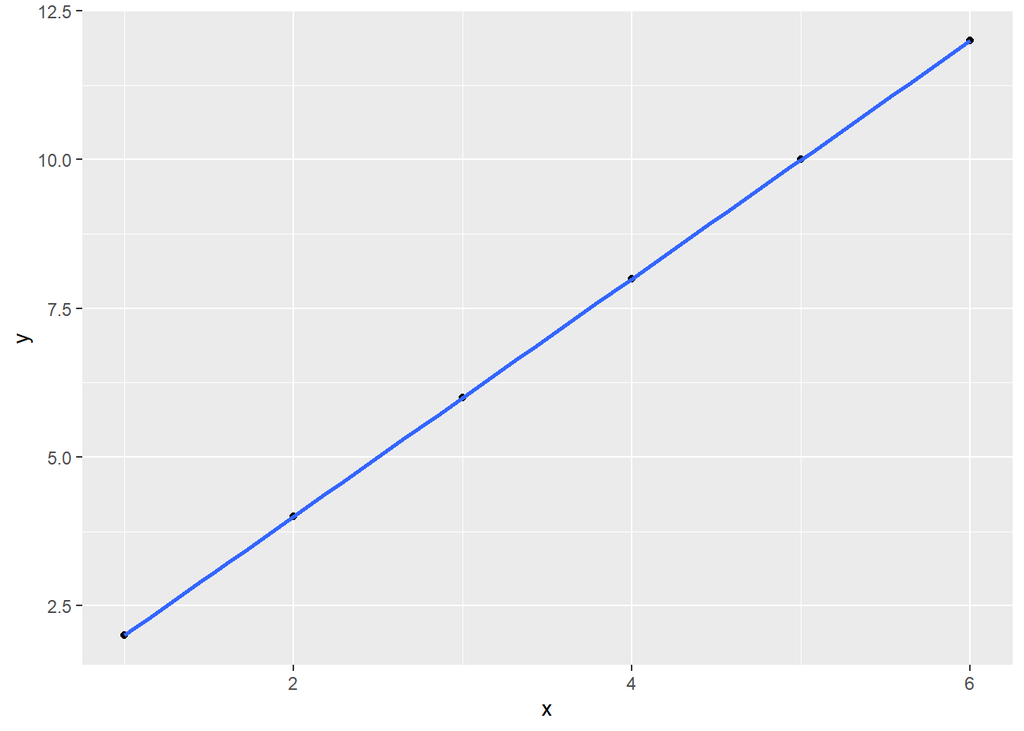

```r
df_toy <- data.frame(x=c(1,2,3,4,5,6),
                     y=c(2,4,6,8,10,12))

library(ggplot2)
ggplot(df_toy, aes(x,y)) + geom_point() + geom_smooth(method=lm)
```

Now throw in just *one* extra point that’s wildly off that line (like $x=2.5$ but $y=39$), and the fitted line barely resembles the true relationship anymore — the $R^2$ can collapse to something as small as $0.008$.

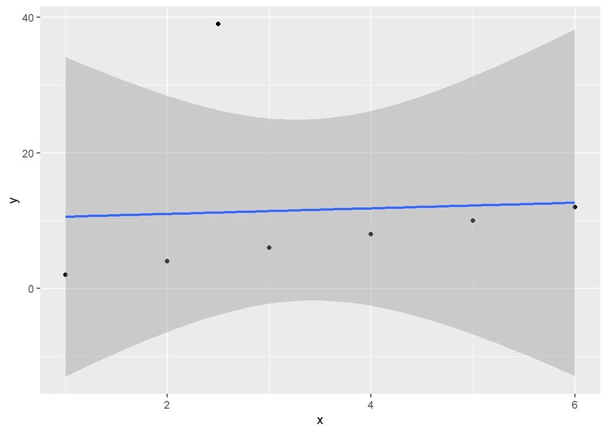

```r
df_toy <- rbind(df_toy,
                data.frame(x=c(2.5),
                           y=c(39)))

ggplot(df_toy, aes(x,y)) + geom_point() + geom_smooth(method=lm)
```

So, a single badly-behaved observation, in other words, can single-handedly hide (or fabricate) a relationship between $x$ and $y$. This is exactly why we want a formal, systematic way of flagging such observations, rather than relying on “*eyeball testing*” of scatterplots.

The formal version of this idea is the **Bonferroni outlier test**. Starting from our GLM’s usual equation $g(E(y_i))=\beta_0+\beta_1x_{1i}+...+\beta_kx_{ki}$, we (conceptually) refit the model $n$ times, once per observation, each time adding one extra predictor: the $j$-th observation’s own, individual dummy variable $z_j$, which equals $1$ for observation $j$ and $0$ for everybody else:
$$g(E(y_i))=c_jz_j+\beta_0+\beta_1x_{1i}+...+\beta_kx_{ki}$$
If the estimated $c_j$ coefficient turns out to be **significantly different from $0$**, that means observation $j$ is single-handedly, significantly distorting (biasing) our fitted equation — i.e. it’s an outlier.

Formally, we’re testing the null hypothesis
$$H_0: c_1=c_2=...=c_n=0$$
against the alternative that at least one of the $c_j$’s isn’t $0$, and if $H_0$ is rejected, it’s worth filtering out the flagged outliers.

Doing this literally, by hand, would mean re-estimating $n$ separate GLMs, one per observation — clearly not something a civilized gentleman wants to code up manually! And since we’re effectively running $n$ separate significance tests at once (one per observation), we also run into the multiple testing problem discussed in Section 8 of Chapter 5: with enough observations, some coefficient is bound to look “significant” purely by chance. This is where the **Bonferroni correction** comes back into play, adjusting the significance threshold (or, equivalently, the p-values) for the fact that we’re conducting $n$ tests simultaneously — exactly what gives the test its name. Thankfully, the `car` package’s `outlierTest` function automates this entire procedure for us: it computes the (Bonferroni-corrected) test for every observation behind the scenes, and simply reports back the most extreme one(s), i.e. the observation(s) for which $H_0$ can be rejected at the common significance levels.

```r
car::outlierTest(poi_reg_extended)
```

```
## No Studentized residuals with Bonferroni p < 0.05
## Largest |rstudent|:
##       rstudent unadjusted p-value Bonferroni p
## 54370 4.534593         5.7715e-06      0.39163
```

```r
car::outlierTest(gamma_reg)
```

```
##       rstudent unadjusted p-value Bonferroni p
## 39324 5.886126         3.9535e-09   1.8281e-05
## 28424 5.689535         1.2739e-08   5.8903e-05
```

If a test rejects $H_0$ for its most extreme observation(s), that’s our signal to consider re-fitting the model without them. For instance, might try refitting the Gamma Regression without observations number $39324$ and $28424$ — precisely because these are the ones flagged by the test as significantly distorting the fitted claim-value equation, so it’s worth checking whether excluding them meaningfully changes our coefficient estimates and conclusions, or whether the model turns out to be robust to their presence regardless.

```r
cars_with_claims_no_outliers <- cars_with_claims[!(rownames(cars_with_claims) %in% c(39324, 28424)),]

gamma_reg_no_outliers <- glm(claim_value ~ veh_value + veh_body + veh_age + gender + area + agecat,
                             family = Gamma(link = "log"),
                             data = cars_with_claims_no_outliers)

gamma_coef_compare <- data.frame(variable = names(gamma_reg$coefficients),
                                 original = as.numeric(gamma_reg$coefficients),
                                 no_outliers = as.numeric(gamma_reg_no_outliers$coefficients))
gamma_coef_compare$diff <- abs(gamma_coef_compare$original - gamma_coef_compare$no_outliers)
gamma_coef_compare[order(gamma_coef_compare$diff, decreasing = TRUE),]
```

|  | variable | original | no_outliers | diff |
| --- | --- | --- | --- | --- |
| 3 | veh_bodyCONVT | 0.69402790 | 0.80856605 | 0.114538143 |
| 10 | veh_bodyRDSTR | -0.99751568 | -0.91649507 | 0.081020610 |
| 23 | areaF | 0.40234052 | 0.46342310 | 0.061082580 |
| 19 | areaB | -0.01624336 | 0.03731113 | 0.053554485 |
| 22 | areaE | 0.17389782 | 0.22730075 | 0.053402938 |
| 20 | areaC | 0.09086822 | 0.14332170 | 0.052453481 |
| 21 | areaD | -0.01070195 | 0.03916862 | 0.049870569 |
| 7 | veh_bodyMCARA | -0.65816037 | -0.62113793 | 0.037022440 |
| 26 | agecat4 | -0.25864267 | -0.29401262 | 0.035369951 |
| 24 | agecat2 | -0.17709082 | -0.21023635 | 0.033145533 |

[output cut: 18 more lines]